# Milestone Report

Bill Su

July 26, 2015

## Introduction

The goal of this report is to showcase the work I have done so far in the Datascience Capstone Project. In this report, I am going to first demostrate codes I have used to load the file and convert them to n-grams. Then I am going to showcase some descriptive summary data I have collected. Finally, I am going to conclude by offering next step in my data analysis and some interesting questions to consider.

## Loading and Cleaning

Here below illustrate my codes in loading and cleaning the data.

Tokenize load the data and parse it into a huge vector of words. It also cleans out punctuations and convert all words to lower cases for convience of analysis. The code is displayed below.

```r
tokenize <- function(file_name){

    strings <- readLines(con =  file(file_name, "r", blocking = FALSE), n = -1)
    splited <- strsplit(strings, " ")
    unlisted <- unlist(splited)
    cleaned <- gsub("[[:punct:]]", "", unlisted)
    result <- tolower(cleaned)
    return (result)
}
```

profane_filter filters out profanity from the datasets. Code is displayed below.

```r
profane_filter <- function(list){
    bad.words <- readLines("~/Google Drive/en_US/bad-words.txt")
    filtered <- subset(list, !(list %in% (intersect(bad.words,list))))
    return (filtered)
}
```

## Pre-Tokenizing Summary Statistics

The goal of this section is to provide some general summary statistics of the data before any tokenizing operations are performed on them. The summary statistics here define the dataset we are going to operate on throughout the project. Here I am going to describe the number of lines and words are in the twitter file, the news file, and the blogs file.

### Twitter

```r
twitter_general <- readLines(con =  file("en_US.twitter.txt", "r", blocking = FALSE), n = -1)
# Number of lines
length(twitter_general)
```

```
## [1] 2360148
```

```r
# Number of words
twitter <- tokenize("en_US.twitter.txt")
twitter_cleaned <- profane_filter(twitter)
length(twitter_cleaned)
```

```
## [1] 29347176
```

```r
# Tables for 10 most frequent words
onecount_twitter <- table(twitter_cleaned)
onecount_twitter <- sort(onecount_twitter, decreasing = TRUE)
onecount_twitter[1:10]
```

```
## twitter_cleaned
##    the     to      i      a    you    and    for     in     of     is
## 934018 786519 712841 606738 542993 433604 384384 376838 358907 357502
```

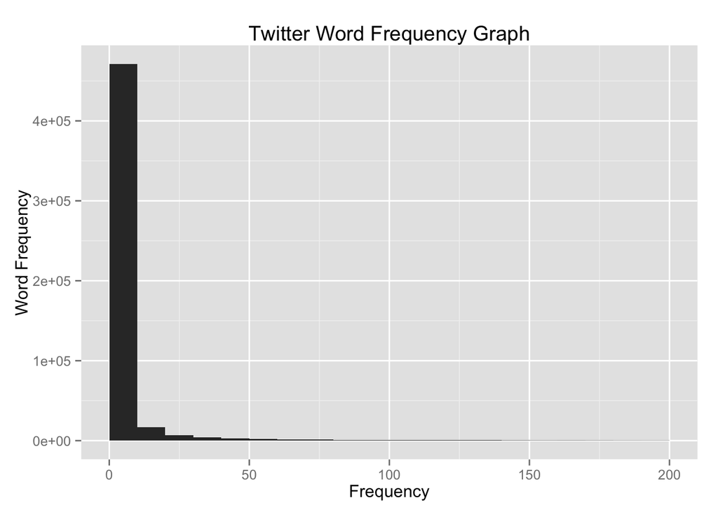

```r
# Word Frequency Histogram
# This graph displays the macro distributional characteristics of the data.
library(ggplot2)
plot_twitter <- qplot(onecount_twitter,binwidth = 10) + ggtitle("Twitter Word Frequency Graph") + xlab("Frequency") + ylab("Word Frequency") + scale_x_continuous(limits=c(0, 200))
plot_twitter
```

### Blogs

```r
blogs_general <- readLines(con =  file("en_US.blogs.txt", "r", blocking = FALSE), n = -1)

# Number of lines
length(blogs_general)
```

```
## [1] 899288
```

```r
# Number of words
blogs <- tokenize("en_US.blogs.txt")
blogs_cleaned <- profane_filter(blogs)
length(blogs_cleaned)
```

```
## [1] 36815397
```

```r
# Tables for 10 most frequent words
onecount_blogs <- table(blogs_cleaned)
onecount_blogs <- sort(onecount_blogs, decreasing = TRUE)
onecount_blogs[1:10]
```

```
## blogs_cleaned
##     the     and      to       a      of       i      in    that      is
## 1855608 1085731 1065637  896183  875003  769075  593480  459474  431796
##      it
##  400869
```

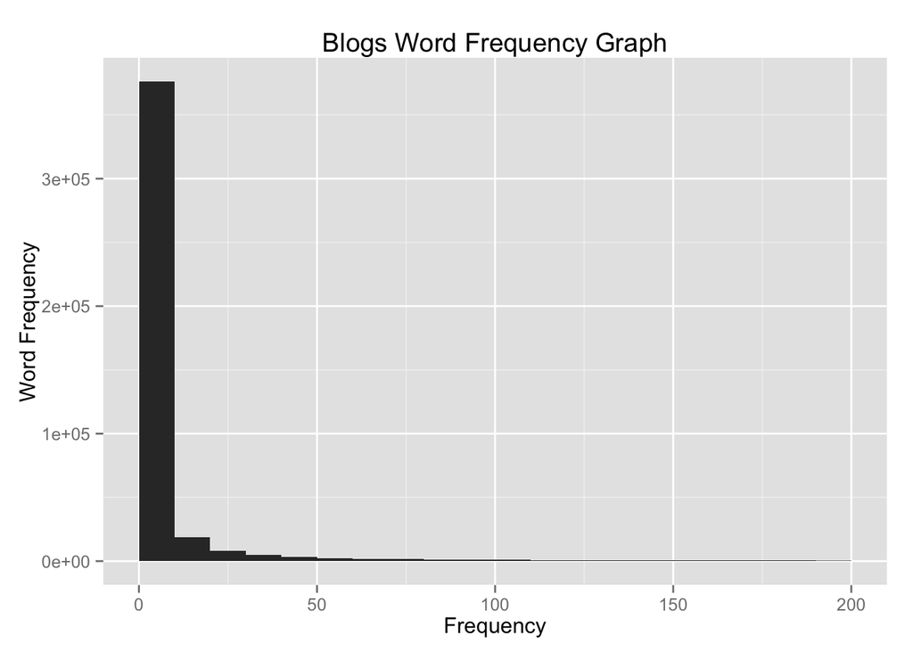

```r
# Word Frequency Histogram
# This graph displays the macro distributional characteristics of the data.
plot_blogs <- qplot(onecount_blogs,binwidth = 10) + ggtitle("Blogs Word Frequency Graph") + xlab("Frequency") + ylab("Word Frequency") + scale_x_continuous(limits=c(0, 200))
plot_blogs
```

### News

```r
news_general <- readLines(con =  file("en_US.news.txt", "r", blocking = FALSE), n = -1)
# Number of lines
length(news_general)
```

```
## [1] 1010242
```

```r
# Number of words
news <- tokenize("en_US.news.txt")
news_cleaned <- profane_filter(news)
length(news_cleaned)
```

```
## [1] 33922650
```

```r
# Tables for 10 most frequent words
onecount_news <- table(news_cleaned)
onecount_news <- sort(onecount_news, decreasing = TRUE)
onecount_news[1:10]
```

```
## news_cleaned
##     the      to     and       a      of      in     for    that      is
## 1970639  900997  884135  874105  771037  673908  351102  346538  284048
##      on
##  266716
```

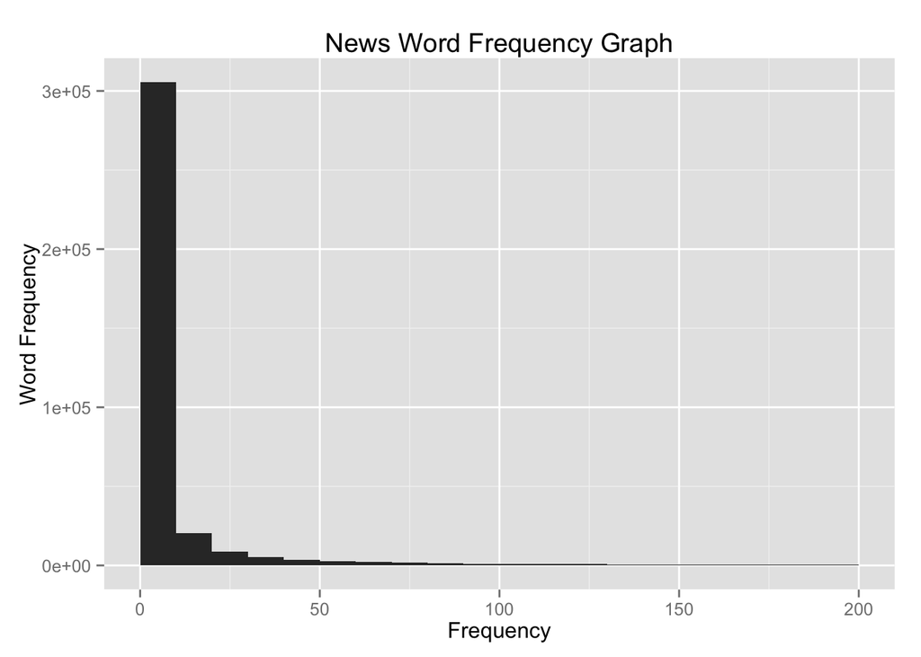

```r
# Word Frequency Histogram
# This graph displays the macro distributional characteristics of the data.
plot_news <- qplot(onecount_news,binwidth = 10) + ggtitle("News Word Frequency Graph") + xlab("Frequency") + ylab("Word Frequency") + scale_x_continuous(limits=c(0, 200))
plot_news
```